# Visualización de datos

Residencia de Epidemiología

## Visualización

“Un simple gráfico ha brindado más información a la mente del analista de datos que cualquier otro dispositivo”. — *John Tukey*

## Objetivos de la visualización

- **Análisis exploratorio**: descubrir y describir patrones en los datos (parte del Análisis Exploratorio de Datos - EDA)
- **Presentación y comunicación**: capacidad de transmitir el mensaje de forma clara y atractiva.

## Señales visuales

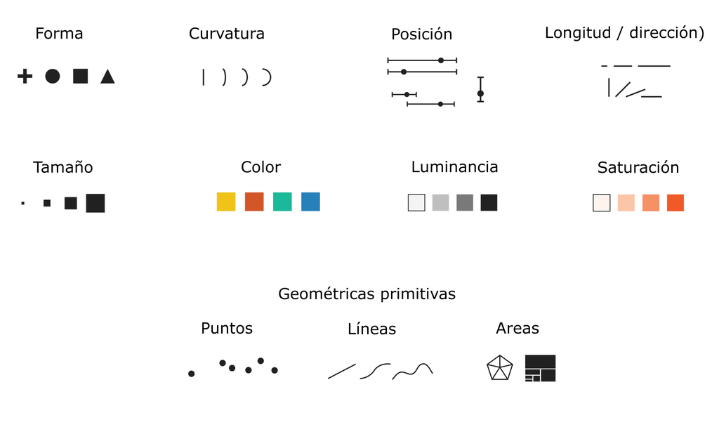

## Gramática de gráficos

De manera similar a la gramática lingüística, *“La gramática de gráficos”* define un conjunto de reglas para construir gráficos estadísticos combinando diferentes tipos de capas.

Esta gramática fue creada por **Leland Wilkinson** (*2005, The Grammar of Graphics (Statistics and Computing). Secaucus, NJ, USA: Springer-Verlag New York, Inc.*)

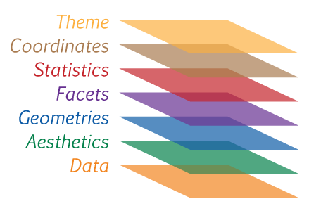

[figure not shown]

[figure not shown]

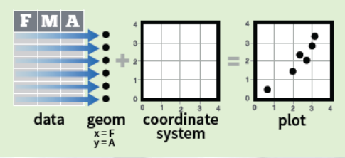

**ggplot2** es un paquete que se autodefine como librería para **“crear elegantes visualizaciones de datos usando una gramática de gráficos”**

El paquete propone un sistema que se basa en la idea que cualquier gráfico se puede construir usando tres componentes básicos:

## Esquema gráfico ggplot2

- **Datos** con estructura “ordenada”
- Mapeo estético (**aes**thetic) de los datos
- Objetos **geom**étricos que dan nombre al tipo de gráfico
- **Coord**enadas que organizan los objetos geométricos
- Escalas (**scale**) definen el rango de valores de las estéticas
- **Facet**as que agrupan en subgráficos

## El esquema básico de un gráfico

```r
<DATOS> |>
  ggplot(mapping = aes(<MAPEO>)) +
  <GEOM_FUNCION>()
```

Las capas posteriores son opcionales. Algunas de ellas son:

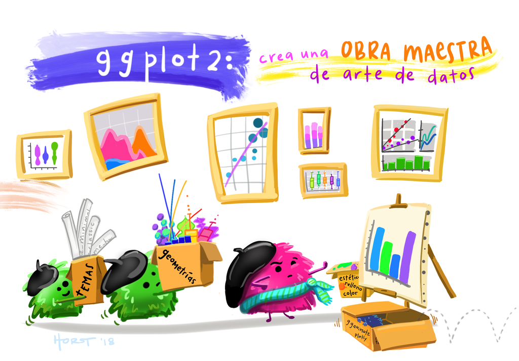

```r
[dataframe] |>
  ggplot(mapping = aes(x = [x-varible],
                       y = [y-variable])) +
  geom_xxx() +
  scale_x_...() +
  scale_y_...() +
  scale_fill_...() +
  otras capas más
```

## Construcción de gráfico paso a paso

La idea en esta presentación es mostrar paso a paso la construcción de un gráfico.

- Partiremos del objetivo deseado, en este caso un tipo de gráfico que ya existe, pero podría ser algún otro ejemplo o un bosquejo de lo imaginado garabateado en un papel.
- El segundo paso es determinar cuales son las variables necesarias para construir ese gráfico y donde se mapean.
- El tercer paso es trabajar con los datos y transformarlos para que estén preparados para graficar.
- El cuarto es el gráfico en si mismo con todas las personalizaciones de sus partes.

## Gráfico objetivo

Queremos construir un gráfico similar a este

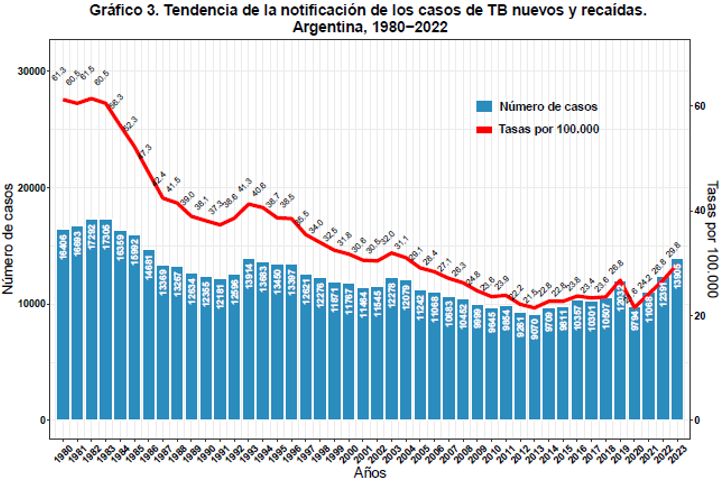

## Variables participantes

- El análisis del modelo indica que hay dos capas geométricas simultáneas: una de **barras** y otra de **líneas**.
- También hay dos ejes `y` (a izquierda **Números de casos** y a derecha **Tasas por 100.000**) y un eje `x` (**Años**)
- Las variables participantes son tres:
  - el número de casos que mapea en `y1`,
  - las tasas que mapean en `y2` y
  - los años de la tendencia que se ubican en `x`.

## Lectura y adecuación de los datos

Importamos datos de la tendencia de TB de la provincia de Santa Fe entre los años 1980 y 2008

```r
library(tidyverse)
library(readxl)

tendencia1 <- read_excel("datos/Tendencia tb 1980 2008 por provincia.xls",
                        sheet = "SFE", range = "A6:A34", col_names = F) |>
   rename("Año" = ...1)

tendencia2 <- read_excel("datos/Tendencia tb 1980 2008 por provincia.xls",
                        sheet = "SFE", range = "D6:E34", col_names = F) |>
  rename("Casos" = ...1,
         "Tasa" = ...2)

tendencia <- tendencia1 |>
  bind_cols(tendencia2)
```

## Lectura y adecuación de los datos

El dataframe necesario para este gráfico nos quedaría así:

```
# A tibble: 29 × 3
     Año Casos  Tasa
   <dbl> <dbl> <dbl>
 1  1980   904  36.2
 2  1981   790  31.2
 3  1982   853  33.3
 4  1983   802  30.9
 5  1984   794  30.2
 6  1985   669  25.1
 7  1986   659  24.5
 8  1987   516  18.9
 9  1988   722  26.2
10  1989   661  23.7
# ℹ 19 more rows
```

## Primer gráfico

Iniciamos con el gráfico de barras. Mapeamos `x` e `y`, indicamos color de relleno e identidad porque las barras se van a construir con el conteo previo (datos agregados)

```r
tendencia |>
  ggplot(aes(x = Año, y = Casos)) +
  geom_bar(stat = "identity",
           fill = "royalblue")
```

## Primer gráfico

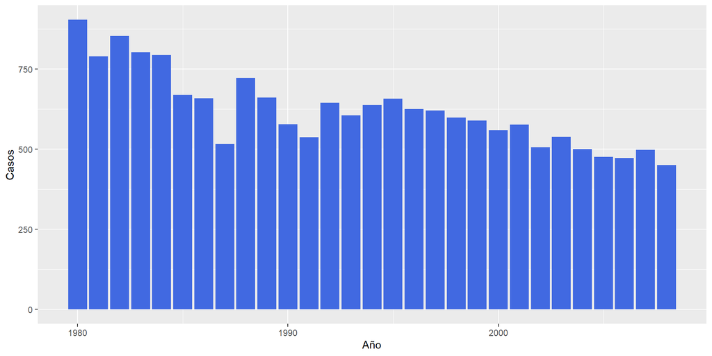

## Capa de texto

Agregamos capa de texto con los valores de los casos.

```r
tendencia |>
  ggplot(aes(x = Año, y = Casos, label = Casos)) +
  geom_bar(stat = "identity",
           fill = "royalblue") +
  geom_text()
```

## Capa de texto

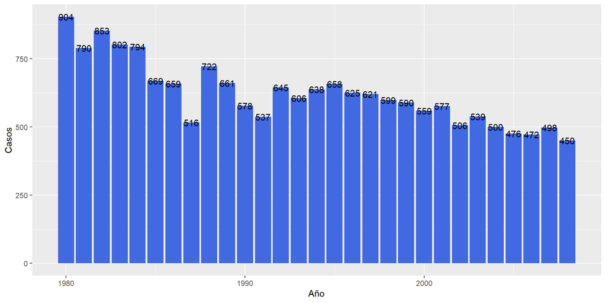

## Capa de texto

Adecuamos los valores en las barras.

```r
tendencia |>
  ggplot(aes(x = Año, y = Casos, label = Casos)) +
  geom_bar(stat = "identity",
           fill = "royalblue") +
  geom_text(hjust = 1.2, vjust = 0.5, angle = 90, color = "white")
```

## Capa de texto

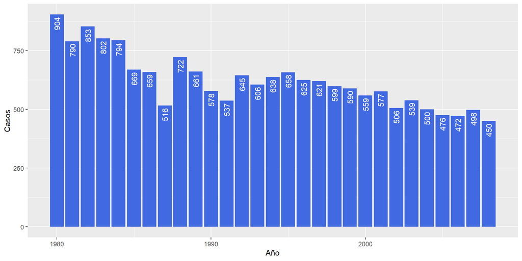

## Eje x

Configuramos eje `x`

```r
tendencia |>
  ggplot(aes(x = Año, y = Casos, label = Casos)) +
  geom_bar(stat = "identity",
           fill = "royalblue") +
  geom_text(hjust = 1.2, vjust = 0.5, angle = 90, color = "white") +
  scale_x_continuous(name = "Años", breaks = seq(1980, 2008, 1))
```

## Eje x

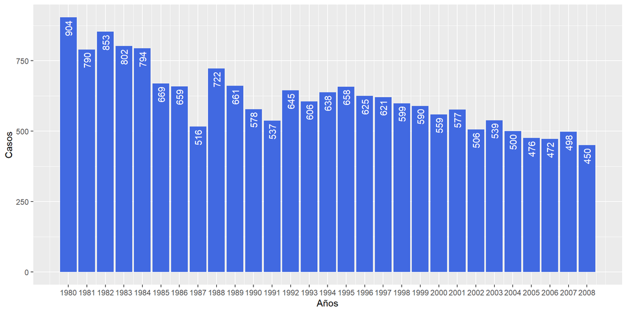

## Eje x

Personalizamos mejor el eje `x` (ángulo de las etiquetas, etc)

```r
tendencia |>
  ggplot(aes(x = Año, y = Casos, label = Casos)) +
  geom_bar(stat = "identity",
           fill = "royalblue") +
  geom_text(hjust = 1.2, vjust = 0.5, angle = 90, color = "white") +
  scale_x_continuous(name = "Años", breaks = seq(1980, 2008, 1)) +
  theme(axis.text.x = element_text(angle = 45, hjust = 1, size = 11))
```

## Eje x

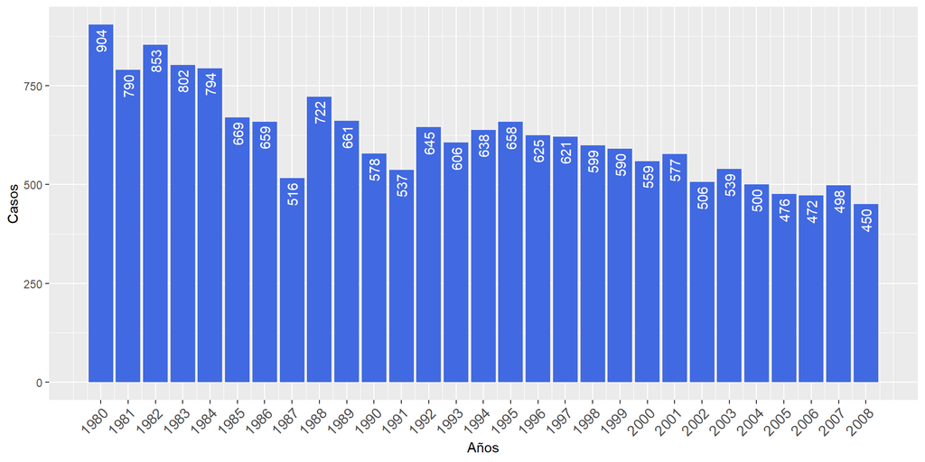

## Eje y

Configuramos el eje `y` asociado a las barras

```r
tendencia |>
  ggplot(aes(x = Año, y = Casos, label = Casos)) +
  geom_bar(stat = "identity",
           fill = "royalblue") +
  geom_text(hjust = 1.2, vjust = 0.5, angle = 90, color = "white") +
  scale_x_continuous(name = "Años", breaks = seq(1980, 2008, 1)) +
  scale_y_continuous(name = "Número de casos", breaks = seq(0, 1000, 200)) +
  theme(axis.text.x = element_text(angle = 45, hjust = 1, size = 11),
        axis.text.y = element_text(size = 11))
```

## Eje y

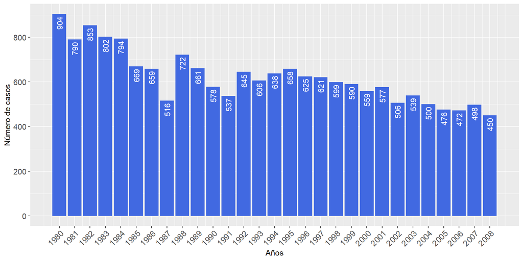

## Segundo gráfico

Incoporamos el segundo gráfico o segunda capa geométrica. Utilizamos una constante para llevar los valores al mismo orden de los valores de las barras.

```r
tendencia |>
  ggplot(aes(x = Año, y = Casos, label = Casos)) +
  geom_bar(stat = "identity",
           fill = "royalblue") +
  geom_line(aes(y = Tasa*35), color = "red", linewidth = 1.5) +
  geom_text(hjust = 1.2, vjust = 0.5, angle = 90, color = "white") +
  scale_x_continuous(name = "Años",
                     breaks = seq(1980, 2008, 1)) +
  scale_y_continuous(name = "Número de casos",
                     breaks = seq(0, 1000, 200),
                     sec.axis = sec_axis(~./35,
                                         name = "Tasa")) +
  theme(axis.text.x = element_text(angle = 45, hjust = 1, size = 11),
        axis.text.y = element_text(size = 11))
```

## Segundo gráfico

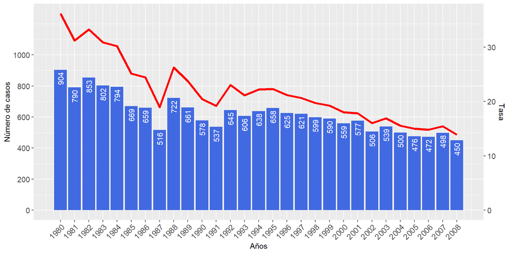

## Etiquetas del segundo gráfico

Agregamos etiquetas asociadas a la capa geométrica `line`

```r
tendencia |>
  ggplot(aes(x = Año, y = Casos, label = Casos)) +
  geom_bar(stat = "identity",
           fill = "royalblue") +
  geom_line(aes(y = Tasa*35), color = "red", linewidth = 1.5) +
  geom_text(hjust = 1.2, vjust = 0.5, angle = 90, color = "white") +
  geom_text(aes(label = round(Tasa,1), y = Tasa*35), angle = 45, hjust = -0.2, vjust = -0.5) +
  scale_x_continuous(name = "Años",
                     breaks = seq(1980, 2008, 1)) +
  scale_y_continuous(name = "Número de casos",
                     breaks = seq(0, 1400, 200),
                     limits = c(0,1400),
                     sec.axis = sec_axis(~./35,
                                         name = "Tasas por 100.000",
                                         breaks = seq(0, 60, 10))) +
  theme(axis.text.x = element_text(angle = 45,
                                   hjust = 1,
                                   size = 11),
        axis.text.y = element_text(size = 11))
```

## Etiquetas del segundo gráfico

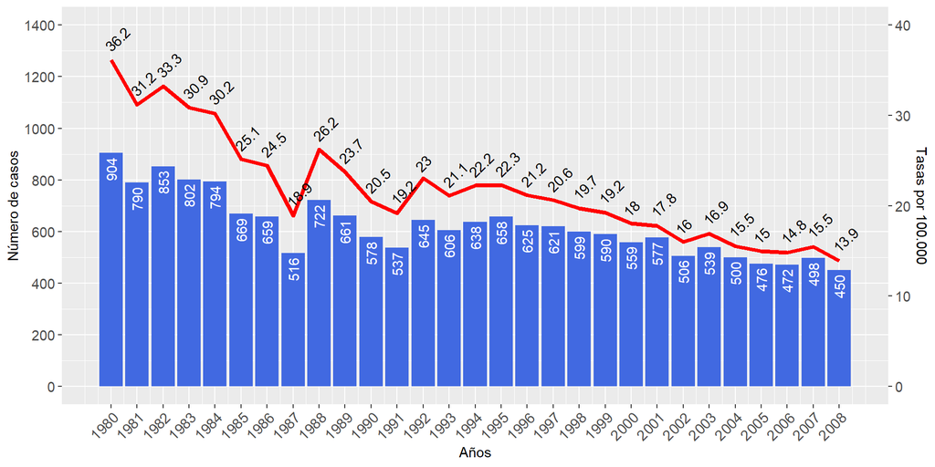

## Leyendas

Al igual que el modelo del gráfico, sumamos dentro del mismo las leyendas

```r
tendencia |>
  ggplot(aes(x = Año, y = Casos, label = Casos, fill = "Número de casos")) +
  geom_bar(stat = "identity") +
  geom_line(aes(y = Tasa*35, color = "Tasas por 100.000"), linewidth = 1.5) +
  geom_text(hjust = 1.2, vjust = 0.5, angle = 90, color = "white") +
  geom_text(aes(label = round(Tasa,1), y = Tasa*35), angle = 45, hjust = -0.2, vjust = -0.5) +
  scale_x_continuous(name = "Años",
                     breaks = seq(1980, 2008, 1)) +
  scale_y_continuous(name = "Número de casos",
                     breaks = seq(0, 1400, 200),
                     limits = c(0,1400),
                     sec.axis = sec_axis(~./35,
                                         name = "Tasas por 100.000",
                                         breaks = seq(0, 60, 10))) +
  scale_fill_manual(values = "royalblue") +
  scale_color_manual(values = "red") +
  theme(axis.text.x = element_text(angle = 45,
                                   hjust = 1,
                                   size = 11),
        axis.text.y = element_text(size = 11),
        legend.position = "inside",
        legend.position.inside = c(0.8, 0.8),
        legend.background = element_rect(fill = "transparent"),
        legend.text.position = "right",
        legend.title=element_blank()) +
  guides(color = guide_legend(order = 0),
         fill = guide_legend(order = 1))
```

## Leyendas

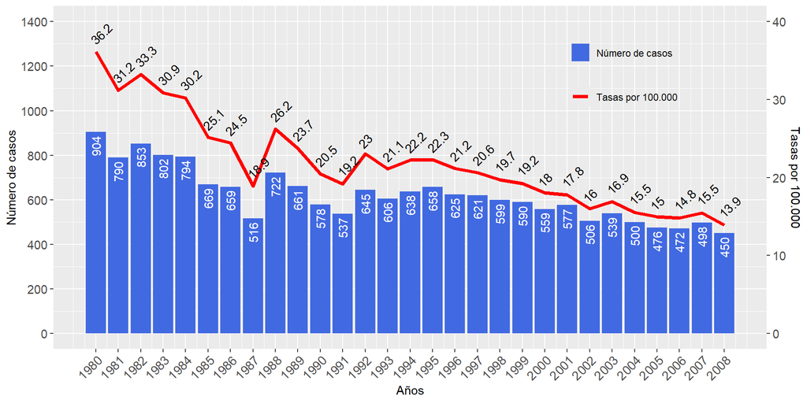

## Título y demás

Por último, definimos estructura de titulo, subtitulo y pie de gráfico (habría que reemplazarlos por la definición de cada uno).

```r
tendencia |>
  ggplot(aes(x = Año, y = Casos, label = Casos, fill = "Número de casos")) +
  geom_bar(stat = "identity") +
  geom_line(aes(y = Tasa*35, color = "Tasas por 100.000"), linewidth = 1.5) +
  geom_text(hjust = 1.2, vjust = 0.5, angle = 90, color = "white") +
  geom_text(aes(label = round(Tasa,1), y = Tasa*35), angle = 45, hjust = -0.2, vjust = -0.5) +
  scale_x_continuous(name = "Años",
                     breaks = seq(1980, 2008, 1)) +
  scale_y_continuous(name = "Número de casos",
                     breaks = seq(0, 1400, 200),
                     limits = c(0,1400),
                     sec.axis = sec_axis(~./35,
                                         name = "Tasas por 100.000",
                                         breaks = seq(0, 60, 10))) +
  scale_fill_manual(values = "royalblue") +
  scale_color_manual(values = "red") +
  labs(title = "Titulo", subtitle = "subtitulo", caption = "pie de grafico" ) +
  theme(axis.text.x = element_text(angle = 45,
                                   hjust = 1,
                                   size = 11),
        axis.text.y = element_text(size = 11),
        legend.position = "inside",
        legend.position.inside = c(0.8, 0.8),
        legend.background = element_rect(fill = "transparent"),
        legend.text.position = "right",
        legend.title=element_blank()) +
  guides(color = guide_legend(order = 0),
         fill = guide_legend(order = 1))
```

## Título y demás

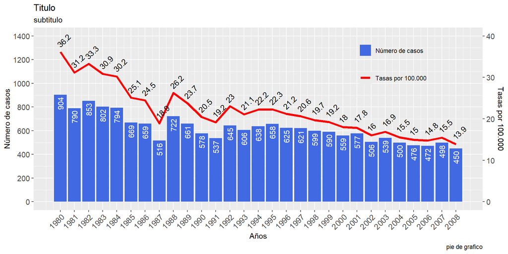

## Exportar gráficos de ggplot2

- Desde el *panel Plot* de RStudio
- En formatos conocidos como JPG, PNG, PDF, etc
- Mayor control con la función *ggsave()*

```r
ggsave(filename,               # nombre del archivo
  plot = last_plot(),          # nombre del objeto gráfico
  device = NULL,               # formato de salida "jpeg", "png", "tiff", "pdf", etc
  width = NA,                  # ancho en unidades de units
  height = NA,                 # alto en unidades de units
  units = c("in", "cm", "mm"), # unidades de medidas
  dpi = 300)                   # resolución de salida en dpi
```

## Gráficos que no hacen lo que quiero

Muchas veces nos encontramos con la situación de crear un gráfico que se ve bien en el panel *Plot* de **RStudio** y cuando lo exportamos o incluímos dentro de un documento de Quarto el tamaño de sus partes (elementos geométricos, textos, leyendas, etc) se achican o agrandan de tal forma que el producto final es feo y/o desproporcionado.

La respuesta a estos problemas tienen que ver con dos conceptos que debemos entender y poder controlar: el **tamaño** y la **resolución**.

## Pantalla

Repasemos algunos conceptos de la imagen en pantalla:

- La pantalla es una matriz de **pixeles**. Todas las imagenes que vemos en ella estan compuesta por ellos.
- La que estoy utilizando ahora, para hacer esta presentación, tiene una **dimensión** de 24 pulgadas con un ratio de aspecto 16/10 (20 x 12,5 pulgadas)
- La **resolución** es de 1920 x 1200, es decir tiene 1920 píxeles de ancho y 1200 píxeles de alto.
- El número de píxeles por pulgada es de 96 (**ppi**).

## Pantalla

Hagamos algunos calculos para ver si todo está en orden:

- **ancho**: 1920 (px) / 96 (px/in) = 20 pulgadas
- **alto**: 1200 (px) / 96 (px/in) = 12,5 pulgadas
- **relación**: 1920 / 1200 = 20 / 12,5 = 16/10

## Archivos de imagen

Las imágenes que se crean con **ggplot2**, por ejemplo, están constituidas por pixeles.

En estas imágenes también se relacionan las dimensiones y las resoluciones.

Para pasar de la dimensión en pulgadas a una cantidad de puntos, por ejemplo al exportar con **ggsave()** se utiliza la cantidad de puntos por pulgadas (dpi).

Si creamos un gráfico de 12 x 10 pulgadas a 300 dpi, el archivo será una matriz de (12 * 300) x (10 * 300) = 3600 x 3000 puntos.

Cuando abrimos el archivo en nuestra computadora, cada punto representa un pixel, lo que da una imagen de 3600 x 3000 px de resolución.

## Archivos de imagen

Imaginemos que tenemos una imagen de 500x500px. Así se vería cada una, con un zoom del 100%, en un monitor de 1080p (1920x1080px) y en otro 4K (3840×2160), ambos del mismo tamaño.

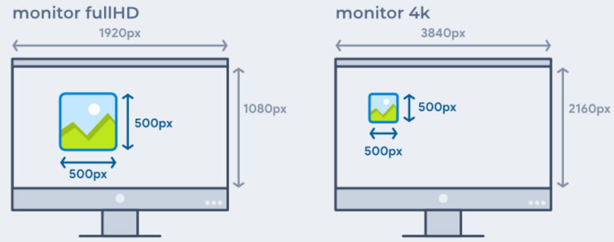

## Experimento práctico

Hagamos un pequeño experimento con un gráfico sencillo basado en los pinguinos.

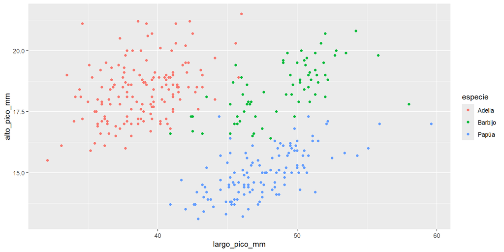

```r
library(tidyverse)
library(datos)

pinguinos |>
    ggplot(aes(largo_pico_mm,
               alto_pico_mm,
               color = especie)) +
    geom_point()
```

## Experimento práctico

```r
ggsave("prueba.png",
       width = 10,
       height = 5,
       dpi = 300)
```

Si calculamos, la salida se almacena como:

- **ancho**: 10 pulgadas * 300 dpi = **3000 px**
- **alto**: 5 pulgadas * 300 dpi = **1500 px**

Ahora si en lugar de guardar el gráfico solo lo visualizaramos en el monitor:

- **ancho**: 10 pulgadas * 96 dpi = **960 px**
- **alto**: 5 pulgadas * 96 dpi = **480 px**

## Experimento práctico

- La relación entre el tamaño de la pantalla y el tamaño físico depende del dpi (puntos por pulgada) del dispositivo gráfico, que es **96** por defecto para la pantalla.
- Luego, si guardamos el gráfico con un dpi mayor o menor, el archivo se guarda como una matriz de puntos usando el nuevo dpi y el tamaño en pulgadas.
- Entonces, cuando se abre en la computadora, la dimensión del tamaño en píxeles es diferente.

> Si visualizamos un gráfico con muchos más pixeles que otro en el mismo espacio (nuestra pantalla) los elementos que lo componen se van a ver siempre más pequeños.

## ¿Por qué es importante esta diferencia?

Importa porque algunos elementos del gráfico se ajustan al espacio disponible, y algunos son fijos y medidos en su dimensión real (cm, mm o pulgadas) como las fuentes de los textos, creando una distorsión al cambiar la dimensión del gráfico o su resolución.

## Tamaño predeterminado en Quarto

| **Formato** | **Por defecto** |
| --- | --- |
| Por defecto | 7 x 5 |
| Diapositivas HTML | 9,5 x 6,5 |
| Diapositivas HTML (reveal.js) | 9 x 5 |
| PDF | 5,5 x 3,5 |
| Diapositivas PDF (Beamer) | 10x7 |
| PowerPoint | 7,5 x 5,5 |
| MS Word, ODT, RTF | 5x4 |
| EPUB | 5x4 |

* Medidas en pulgadas

## Grafico con tamaño predeterminado (9 x 5”)

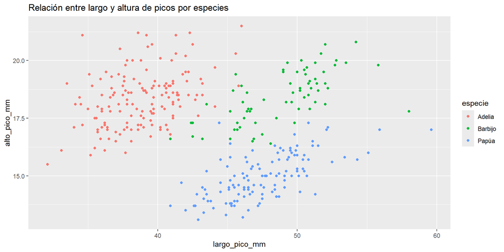

## Grafico con tamaño al 50% (4.5 x 2.5”)

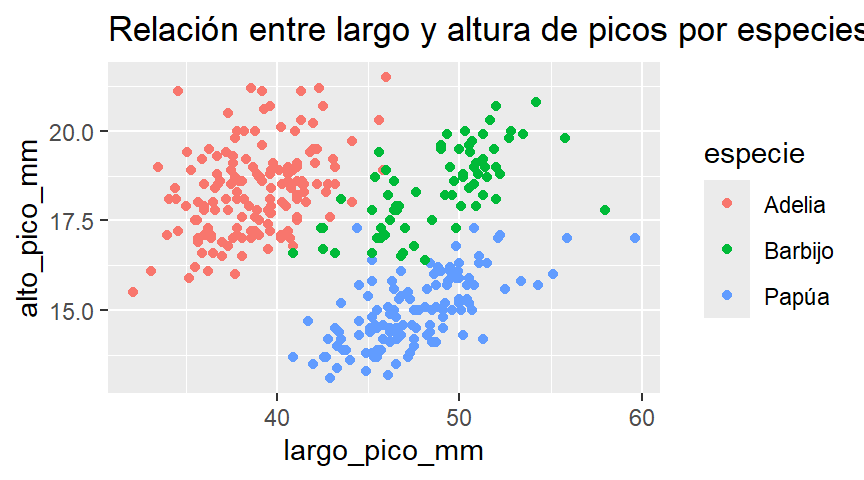

## Grafico con tamaño 12 x 6.67”

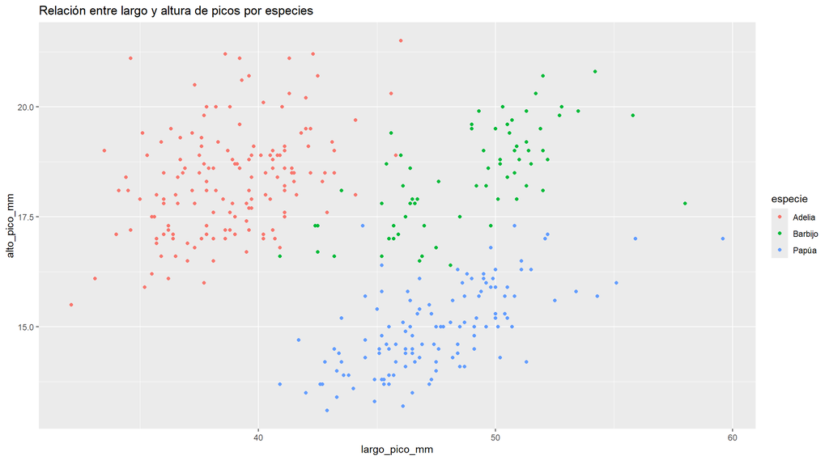

## Archivos exportados

Comparemos dos archivos exportados desde **ggplot2**:

*font_prueba1_5x5_300.png*

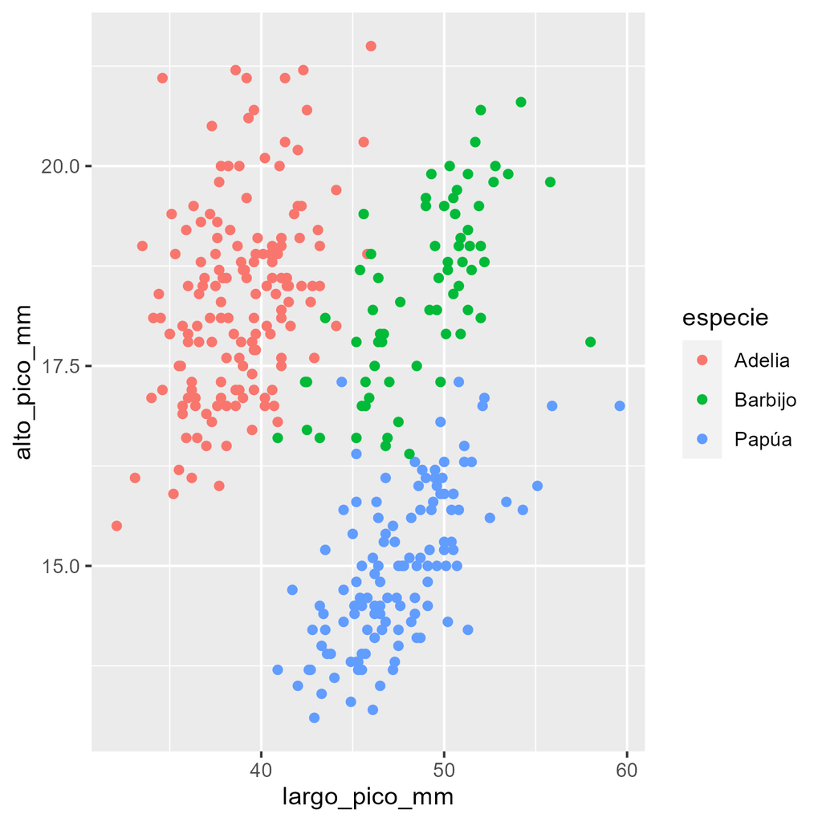

*font_prueba1_10x10_300.png*

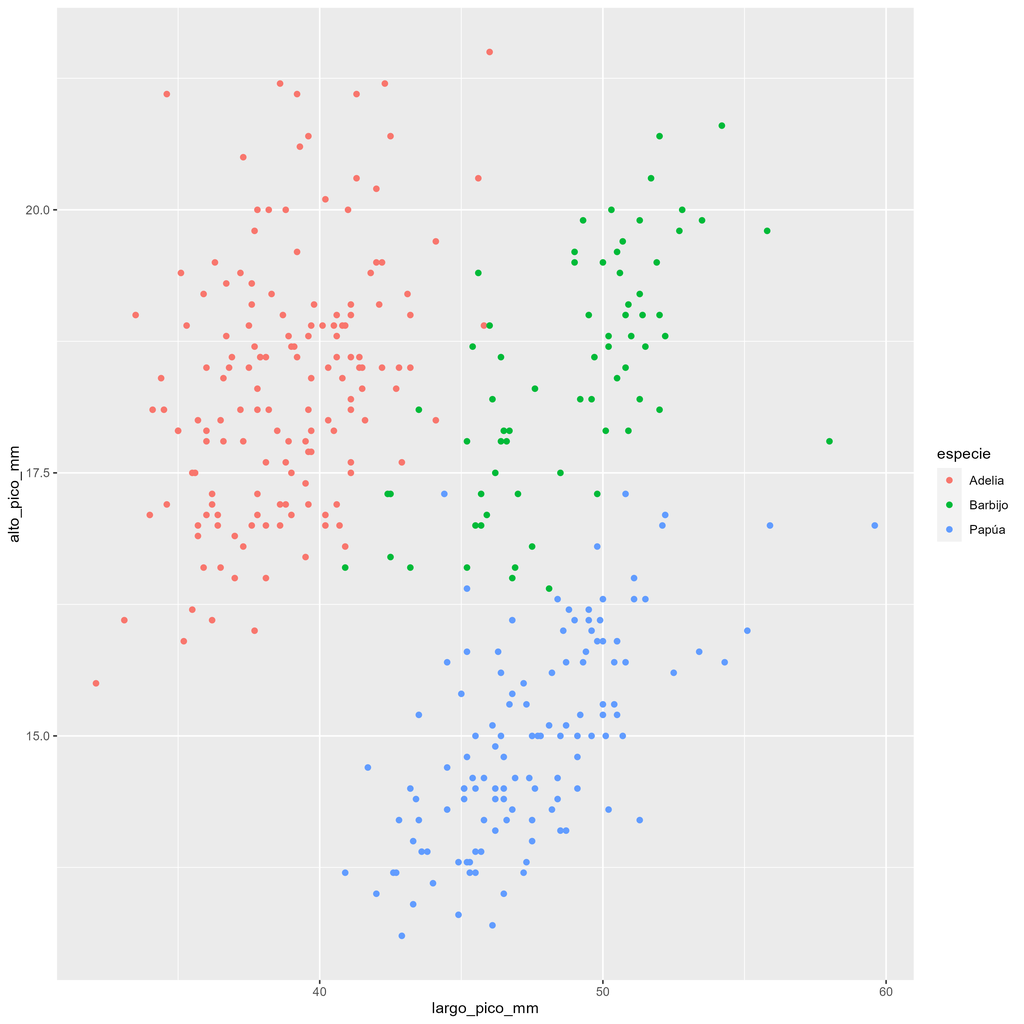

## Problemas con fuentes

Observamos que el tamaño del punto y la fuente parecen más pequeños en el gráfico de la derecha.

De hecho no son más pequeños, siguen teniendo el mismo tamaño en pulgadas, y como guardamos con la misma resolución (dpi = 300), tienen el mismo número de puntos (tamaño en pulgadas * 300).

La fuente del gráfico aparece más pequeña porque el segundo gráfico es más grande (3000x3000 frente a 1500x1500) y se reduce su aspecto para que el gráfico entre el espacio de la pantalla.

## Diferencia en tamaño de fuentes

Además tenemos otro problema. De forma predeterminada, el tamaño de las fuentes de la configuración de `theme()` está definido en pts. (15 significa *15 puntos* - pts-).

En cambio, en la capa `geom_text()`, el tamaño se define en mm, por lo que 15 es *15 mm*.

### ¿Cuál es la relación entre pts y mm o in?

`1 punto` = **1/72 pulgadas**

`1 punto` = **0,35 mm**

## Diferencia en tamaño de fuentes

Entonces si queremos que el texto tenga el mismo tamaño que el título, el tamaño en mm será 15 pt * 0,35 pt/mm = 5,25 mm

En **ggplot**, hay una constante definida para realizar la conversión, **.pt = 2,845276.** (1/.pt = 0,35). Podemos escribir **.pt** en la consola y mostrará su valor:

```r
.pt
```

```
[1] 2.845276
```

```r
1/.pt
```

```
[1] 0.3514598
```

Entonces para hacer la conversión:

de pt a mm : **mm** = `pt / .pt` -> 15 / 2,845276 = 5,27 mm

de mm a pt : **pt** = `mm * .pt` -> 5,27 * 2,845276 = 15 pts

## Diferencia en tamaño de fuentes

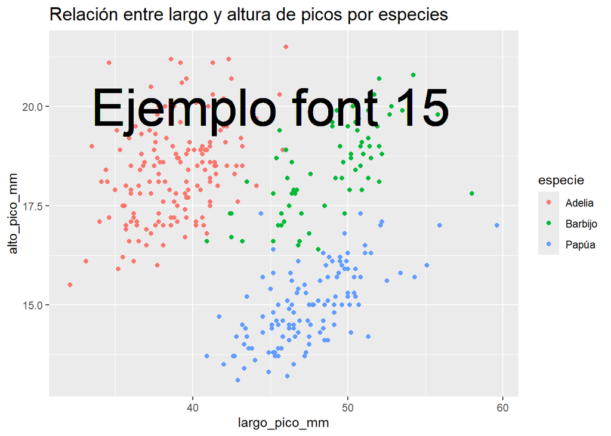

```r
pinguinos |>
    ggplot(aes(x = largo_pico_mm,
               y = alto_pico_mm,
               color = especie)) +
  geom_point() +
  geom_text(x = 45,
            y = 20,
            label = "Ejemplo font 15",
            size = 15,
            inherit.aes = FALSE) +
  labs(title = "Relación entre largo y altura de picos por especies") +
  theme(plot.title = element_text(size = 15))
```

## Diferencia en tamaño de fuentes

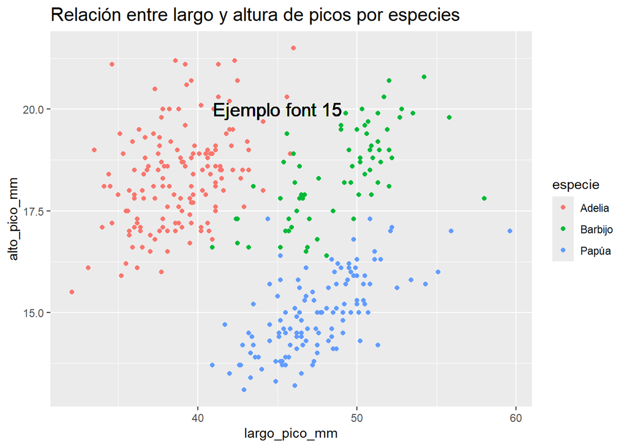

```r
pinguinos |>
    ggplot(aes(x = largo_pico_mm,
               y = alto_pico_mm,
               color = especie)) +
  geom_point()+
  geom_text(x = 45,
            y = 20,
            label = "Ejemplo font 15",
            size = 15/.pt,
            inherit.aes = FALSE) +
  labs(title = "Relación entre largo y altura de picos por especies") +
  theme(plot.title = element_text(size = 15))
```